# **Facial Emotion Detection**

#### **Repurposing ResNet's Architecture**

```python
#import model architecture
imported_model_Resnet = ap.ResNet101(include_top = False, weights = "imagenet", input_shape=(48,48,3))

# Getting only the conv layers for transfer learning.
transfer_layer = imported_model_Resnet.get_layer('conv5_block3_out')
resnet_conv_layers = Model(inputs=imported_model_Resnet.input, outputs=transfer_layer.output)

# make sure pre-trained layers WILL be trained on our data
resnet_conv_layers.trainable=True
```

```python
def cnn_model_Resnet_2():
  # Intializing a sequential model
  model = Sequential()

  model.add(resnet_conv_layers)

  model.add(Flatten())

  ### BASE MODEL ###
  model.add(get_base_model_2())

  # Compile model
  model.compile(loss = 'categorical_crossentropy',
              metrics = ['accuracy'],
              optimizer=tf.keras.optimizers.Adam(learning_rate=0.001))

  return model
```

```python
#load/compile model
cnn_model_ResNet_2 = cnn_model_Resnet_2()

cnn_history_ResNet_2 = train_model( cnn_model_ResNet_2, 40, 'RGB')
```

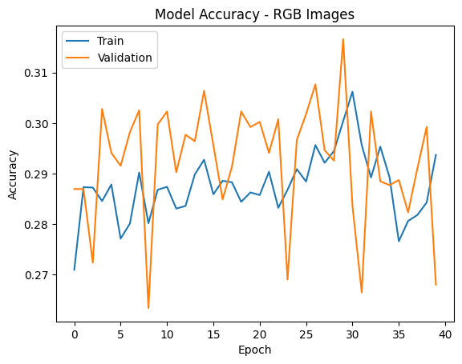

```python
#plot model performnce
plot_model(cnn_history_ResNet_2, 'RGB')
```

```python
# test model
test_model(cnn_model_ResNet_2, 'RGB')
```

```
{'happy': 0, 'sad': 1, 'neutral': 2, 'surprise': 3}
              precision    recall  f1-score   support

           0       0.24      0.53      0.33        30
           1       0.38      0.26      0.31        31
           2       0.00      0.00      0.00        31
           3       0.17      0.21      0.19        19

    accuracy                           0.25       111
   macro avg       0.20      0.25      0.21       111
weighted avg       0.20      0.25      0.21       111
```

**Observations:** cnn_model_ResNet_2

- being able to train the ResNet architecture has had little benefit, as the model performed similarly to the original pre-trained model (poorly)

#### **Repurposing the EfficientNet Architecture**

```python
#import the EfficientNet model
imported_model_EfficientNet = ap.EfficientNetV2B2(include_top=False,weights="imagenet", input_shape= (48, 48, 3))

# Getting only the conv layers for transfer learning.
transfer_layer = imported_model_EfficientNet.get_layer('top_activation')
efficientNet_conv_layers = Model(inputs=imported_model_EfficientNet.input, outputs=transfer_layer.output)

# make sure pre-trained layers WILL be trained on our data
efficientNet_conv_layers.trainable=True
```

```
Downloading data from https://storage.googleapis.com/tensorflow/keras-applications/efficientnet_v2/efficientnetv2-b2_notop.h5
```

```python
def cnn_model_EffNet_2():
  # Intializing a sequential model
  model = Sequential()

  model.add(efficientNet_conv_layers)

  model.add(Flatten())

  ### BASE MODEL ###
  model.add(get_base_model_2())

  # Compile model
  model.compile(loss = 'categorical_crossentropy',
              metrics = ['accuracy'],
              optimizer=tf.keras.optimizers.Adam(learning_rate=0.001))

  return model
```

```python
#load/compile the model
cnn_model_EffNet_2 = cnn_model_EffNet_2()

#train the model
cnn_history_EffNet_2 = train_model(cnn_model_EffNet_2, 20, 'RGB')
```

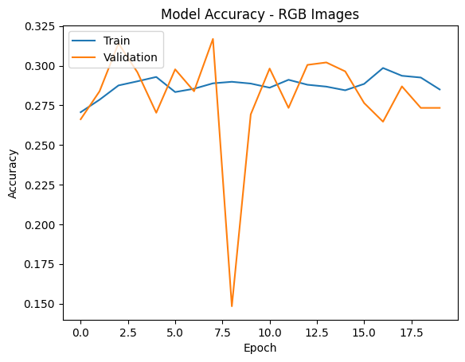

```python
#plot performance
plot_model(cnn_history_EffNet_2, 'RGB')
```

```python
#test model
test_model(cnn_model_EffNet_2, 'RGB')
```

```
{'happy': 0, 'sad': 1, 'neutral': 2, 'surprise': 3}
              precision    recall  f1-score   support

           0       0.00      0.00      0.00        30
           1       0.28      1.00      0.44        31
           2       0.00      0.00      0.00        31
           3       0.00      0.00      0.00        19

    accuracy                           0.28       111
   macro avg       0.07      0.25      0.11       111
weighted avg       0.08      0.28      0.12       111
```

**Observations:**

- Similar to ResNet, being able to trian the model has had little to no benefit
- the model has performed very poorly and is not even showing signs of learning the training data

## **Final Model (Milestone)**

### **Plotting the Confusion Matrix for the chosen final model**

cnn_model_3c is the best model we have been able to produce, achieving an accuracy of about 75% on the test data

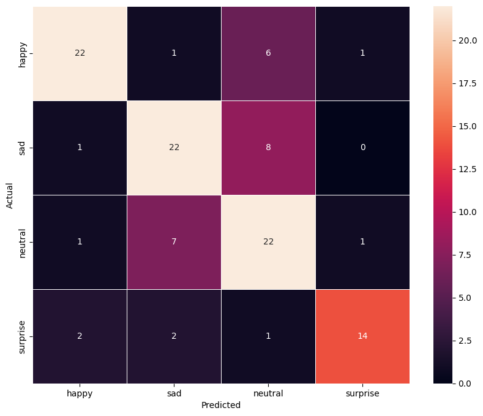

```python
# test model to get y_test_arg and y_pred_arg variables
y_pred=cnn_model_3c_gen2.predict(x_test_norm_GRAY)
y_pred_arg=np.argmax(y_pred,axis=1)
y_test_arg=np.argmax(y_test_encoded,axis=1)

# Plotting the Confusion Matrix
confusion_matrix = tf.math.confusion_matrix(y_test_arg,y_pred_arg)
f, ax = plt.subplots(figsize=(10, 8))
sns.heatmap(
    confusion_matrix,
    annot=True,
    linewidths=.4,
    fmt="d",
    square=True,
    ax=ax,
    xticklabels = list(emotion_dict.keys()),
    yticklabels = list(emotion_dict.keys())
)
plt.ylabel('Actual')
plt.xlabel('Predicted')
plt.show()
```

**Observations and Insights:**

- sad and neutral seem to be the most difficult emotions to correctly identify, the most common mistake is for the model to get these two emotions confused
- this refects the lower recall, precision and f-1 scores the model has on neutral and sad categories

# **Milestone Conclusions**

# **Milestone Insights**

### **Refined insights**:

What are the most meaningful insights from the data relevant to the problem?

- None of our models were able to exceed 75% accuracy on the test data, none of our models hit 75% accuracy on the validation data. Any model that makes it close to 70% accurcy on the validation data seems to stop learning (they will overfit the data, but validation accuracy does not improve)
- this could mean that 25%-30% of faces in our validation data contain features that are not adequately represented in the training data
- alternatively, it could men there is a problem with our data sets
- we removed images that had exact duplicates, but similar images (ones that differ by even just one pixel) could still remain in our datasets (which could result in biases or information leakage)
- additionally, there could be mislabeled images which would impact perforance negatively
- if there are any issues with the datasets, fixing such problems could substantially improve model accuracy going forward, this is a matter that is definitely worth exploring further

### **Comparison of various techniques and their relative performance**:

How do different techniques perform? Which one is performing relatively better? Is there scope to improve the performance further?

- There is almost certainly scope to improve the model. I have only scratched the surface of all the possible architectures that could be created, and seemingly small changes can have substantial impact to perforance
- the best technique seems to be creating smaller sub-structures and add such structures on top of one another. A well designed layer repeated a few times seems to beat out a large, but unsophisticted model (ie. one with only a lot of nodes and dense layers)
- BatchNormalization, leakyRelu and dropout layers, seem to go a long way when sprinkled in throughout the model layers (instead of just adding them at the end of the model)
- Transfer learning was not a good strategy as it seems the models were designed and trained for specific purposes (purposes which do not align with the problem of facial expression recognition)
- it mkes sense to purpuse designing our own model because we can design and tweak it to meet the needs specific for our task

### **Proposal for the final solution design**:

What model do you propose to be adopted? Why is this the best solution to adopt?

- cnn_model_3c should be adopted because it is the model which has achieved the highest accurcies on the validation and test data. The model is already large enough that training it has become cumbersome, so, going forward, it may make more sense to lessen the complexity of the model in order to make it more efficient. However, since the model only needs to be trained prior to being deployed, the amount of time to train the model need not be taken into account when considering which to deploy.
- for the most part, cnn_model_3c used two different "sub-structures" and simply repeated these structures with minor tweaks (usually tweaking the number of nodes), while this approch has proven effective, there are all sorts of sub-structures that should be explored. It is very possible that the final model could look substantially different from the current version if a different sub-structures are found to be more promising than the ones used in cnn_model_3c
- most of the experimentation revolved around manipulating network architecture, hyperparameters were not relly explored. Now that we have a few decent models to use as a starting point further exploration of hyperparameters should occur

## Refining cnn_model_3c (cnn_model_3c2)

cnn_model_3c is very large and takes a long time to train, the model can likely be simplified and improved

```python
def cnn_model_3c2():
  model = Sequential()

  model.add(Conv2D(64, (2, 2), padding="same", input_shape = (48,48,1), activation = 'relu'))
  model.add(BatchNormalization())
  model.add(LeakyReLU(0.1))
  #model.add(MaxPooling2D(pool_size=(2, 2)))
  model.add(Dropout(.2))

  #decreased # of filters
  model.add(Conv2D(64, (2, 2), padding="same", activation = 'relu'))
  model.add(BatchNormalization())
  model.add(LeakyReLU(0.1))
 # model.add(MaxPooling2D(pool_size=(2, 2)))
  model.add(Dropout(.2))

#decreased # of filters
  model.add(Conv2D(128, (2, 2), padding="same", activation = 'relu'))
  model.add(BatchNormalization())
  model.add(LeakyReLU(0.1))
  #model.add(MaxPooling2D(pool_size=(2, 2)))
  model.add(Dropout(.2))

#decreased # of filters
  model.add(Conv2D(128, (2, 2), padding="same", activation = 'relu'))
  model.add(BatchNormalization())
  model.add(LeakyReLU(0.1))
  model.add(MaxPooling2D(pool_size=(2, 2)))
  model.add(Dropout(.2))

  #decreased # of filters
  model.add(Conv2D(256, (2, 2), padding="same", activation = 'relu'))
  model.add(BatchNormalization())
  model.add(LeakyReLU(0.1))
  model.add(MaxPooling2D(pool_size=(2, 2)))
  model.add(Dropout(.2))

  #decreased # of filters
  model.add(Conv2D(256, (2, 2), padding="same", activation = 'relu'))
  model.add(BatchNormalization())
  model.add(LeakyReLU(0.1))
  model.add(MaxPooling2D(pool_size=(2, 2)))
  model.add(Dropout(.2))

  model.add(Conv2D(128, (2, 2), padding="same", activation = 'relu'))
  model.add(BatchNormalization())
  model.add(LeakyReLU(0.1))
  model.add(MaxPooling2D(pool_size=(2, 2)))
  model.add(Dropout(.2))

  model.add(Flatten())

  model.add(Dense(256, activation = 'relu'))
  model.add(BatchNormalization())
  model.add(LeakyReLU(0.1))
  model.add(Dropout(.2))

  model.add(Dense(512, activation = 'relu'))
  model.add(BatchNormalization())
  model.add(LeakyReLU(0.1))
  model.add(Dropout(.2))

  model.add(Dense(512, activation = 'relu'))
  model.add(BatchNormalization())
  model.add(LeakyReLU(0.1))
  model.add(Dropout(.2))

#removed 5 'substructures,' 3 with 1024 nodes, 2 with 512 nodes

  model.add(Dense(512, activation = 'relu'))
  model.add(BatchNormalization())
  model.add(LeakyReLU(0.1))
  model.add(Dropout(.2))

  model.add(Dense(512, activation = 'relu'))
  model.add(BatchNormalization())
  model.add(LeakyReLU(0.1))
  model.add(Dropout(.2))

  model.add(Dense(256, activation = 'relu'))
  model.add(BatchNormalization())
  model.add(LeakyReLU(0.1))
  model.add(Dropout(.2))

  model.add(Dense(4, activation='softmax'))


  # Compile model
  model.compile(loss = 'categorical_crossentropy',
              metrics = ['accuracy'],
              optimizer=tf.keras.optimizers.Adam(learning_rate=0.001))

  return model
```

```python
##load/compile model
cnn_model_3c2 = cnn_model_3c2()
```

```python
#train model
cnn_history_3c2 = train_model(cnn_model_3c2, 50, 'GRAY')
```

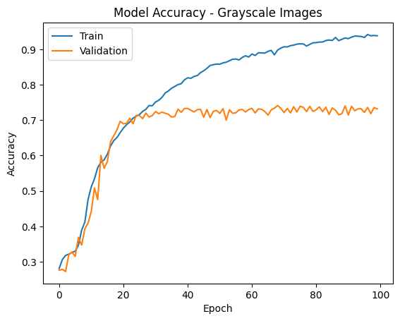

```python
#plot performance (over 100 epochs)
plot_model(cnn_history_3c2, 'GRAY')
```

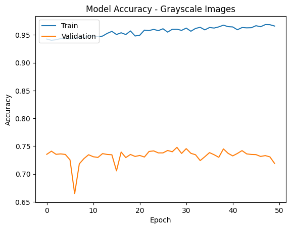

```python
#plot performance for an additional 50 epochs (epochs 101 to 150)
plot_model(cnn_history_3c2, 'GRAY')
```

```python
#test model (after 150 epochs)
test_model(cnn_model_3c2, 'GRAY')
```

```
{'happy': 0, 'sad': 1, 'neutral': 2, 'surprise': 3}
              precision    recall  f1-score   support

           0       0.81      0.83      0.82        30
           1       0.90      0.61      0.73        31
           2       0.62      0.90      0.74        31
           3       0.93      0.68      0.79        19

    accuracy                           0.77       111
   macro avg       0.82      0.76      0.77       111
weighted avg       0.80      0.77      0.77       111
```

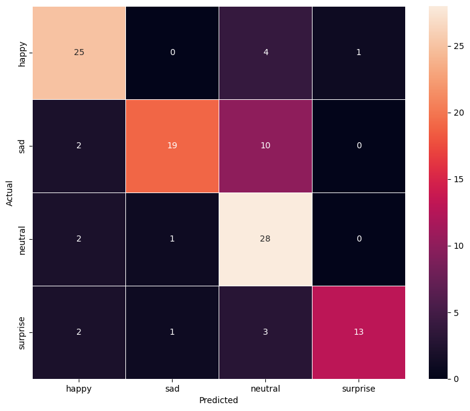

```python
# test model to get y_test_arg and y_pred_arg variables
y_pred=cnn_model_3c2.predict(x_test_norm_GRAY)
y_pred_arg=np.argmax(y_pred,axis=1)
y_test_arg=np.argmax(y_test_encoded,axis=1)

# Plotting the Confusion Matrix
confusion_matrix = tf.math.confusion_matrix(y_test_arg,y_pred_arg)
f, ax = plt.subplots(figsize=(10, 8))
sns.heatmap(
    confusion_matrix,
    annot=True,
    linewidths=.4,
    fmt="d",
    square=True,
    ax=ax,
    xticklabels = list(emotion_dict.keys()),
    yticklabels = list(emotion_dict.keys())
)
plt.ylabel('Actual')
plt.xlabel('Predicted')
plt.show()
```

**Observations:** cnn_model_3c2

- This model is a meaningful improvement upon cnn_model_3c. Not only is it substantially faster to train, it has also achieved the highest accuracies on the test data yet.
- Based on the confusion matrix, we can see that the model has a tendancy to mistake sad photos for neutral photos
- Based on the plot of the training vs validation accuracies we can once again see clear "wall" around 75% accuracy which our models have not been able to exceed...why is it that all of our models have such difficulty with around 25% of the data?
- let's explore this in more depth to see if there is, indeed, some issue with our datasets (like mislabeled or very similar images)

## **Utilizing a different dataset**

If there is some issue with our datasets causing a systematic inability to exceed about 75% accuracy, using a different dataset should resolve the issue let's see how our model performs when trained on a different set of images.

- the new datasets to be used were obtained from https://www.kaggle.com/datasets/msambare/fer2013 (we will not utilize the fear, disgust or anger images from the dataset)

```python
# Storing the path of the data file from the Google drive
folder_path = '/content/drive/MyDrive/MIT_DataScience/Capstone Project/Secondary Dataset/'
```

```python
# create dataframe to store images and relevant features
image_df_2 = pd.DataFrame(columns = ['emotion', 'data type', 'path', 'image','image hash','pixel data rgb','pixel data gray'])

counter = 0

data_type_path = os.listdir(folder_path)

# get each data type folder (ie. training, validation, test)
for data_type in data_type_path:
  emotion_type_path = os.listdir(folder_path + data_type )
  # get each emotion type folder (ie. happy, sad, neutral, surprise)
  for emotion in emotion_type_path:
    image_path = os.listdir(folder_path +  data_type + '/' + emotion)
    for face_image in image_path:
      # get the path for an individual image
      path_of_image = folder_path + data_type +'/'+  emotion + '/' + face_image

      # load the image, as color and grayscale image
      img_rgb = load_img(folder_path + data_type +'/'+  emotion + '/' + face_image, color_mode='rgb')
      img_gray = load_img(folder_path + data_type +'/'+  emotion + '/' + face_image, color_mode='grayscale')

      # this will assign a unique hash to every image (which we will use to check for duplicates)
      image_hash = imagehash.average_hash(img_gray)

      #convert color and grayscale images into separate pixel arrays
      pixel_array_rgb = img_to_array(img_rgb)
      pixel_array_gray = img_to_array(img_gray)

      # add path, emotion type and data type into a dataframe
      image_df_2 = image_df_2.append({'emotion' : emotion, 'data type' : data_type, 'path' : path_of_image,"image":img_rgb,'image hash':image_hash, 'pixel data rgb':pixel_array_rgb, 'pixel data gray':pixel_array_gray},ignore_index = True)
```

```python
#preview datframe
image_df_2
```

|  | emotion | data type | path | image | image hash | pixel data rgb | pixel data gray |
| --- | --- | --- | --- | --- | --- | --- | --- |
| 0 | sad | train | /content/drive/MyDrive/MIT_DataScience/Capston... | <PIL.Image.Image image mode=RGB size=48x48 at ... | 3e7c7c7c7c3c1c0a | [[[51.0, 51.0, 51.0], [60.0, 60.0, 60.0], [57.... | [[[51.0], [60.0], [57.0], [53.0], [45.0], [52.... |
| 1 | sad | train | /content/drive/MyDrive/MIT_DataScience/Capston... | <PIL.Image.Image image mode=RGB size=48x48 at ... | 7f330fc7e3011133 | [[[45.0, 45.0, 45.0], [88.0, 88.0, 88.0], [119... | [[[45.0], [88.0], [119.0], [139.0], [148.0], [... |
| 2 | sad | train | /content/drive/MyDrive/MIT_DataScience/Capston... | <PIL.Image.Image image mode=RGB size=48x48 at ... | 00006040d9fff3e3 | [[[152.0, 152.0, 152.0], [128.0, 128.0, 128.0]... | [[[152.0], [128.0], [145.0], [128.0], [74.0], ... |
| 3 | sad | train | /content/drive/MyDrive/MIT_DataScience/Capston... | <PIL.Image.Image image mode=RGB size=48x48 at ... | c8dce4e4fee6f0f8 | [[[236.0, 236.0, 236.0], [236.0, 236.0, 236.0]... | [[[236.0], [236.0], [236.0], [236.0], [236.0],... |
| 4 | sad | train | /content/drive/MyDrive/MIT_DataScience/Capston... | <PIL.Image.Image image mode=RGB size=48x48 at ... | fd981818f6e6c0c0 | [[[252.0, 252.0, 252.0], [250.0, 250.0, 250.0]... | [[[252.0], [250.0], [252.0], [254.0], [250.0],... |
| ... | ... | ... | ... | ... | ... | ... | ... |
| 25251 | happy | test | /content/drive/MyDrive/MIT_DataScience/Capston... | <PIL.Image.Image image mode=RGB size=48x48 at ... | bc3e1a7a7e063c38 | [[[222.0, 222.0, 222.0], [226.0, 226.0, 226.0]... | [[[222.0], [226.0], [220.0], [223.0], [205.0],... |
| 25252 | happy | test | /content/drive/MyDrive/MIT_DataScience/Capston... | <PIL.Image.Image image mode=RGB size=48x48 at ... | 3070f0c0c093e3e1 | [[[145.0, 145.0, 145.0], [113.0, 113.0, 113.0]... | [[[145.0], [113.0], [110.0], [96.0], [95.0], [... |
| 25253 | happy | test | /content/drive/MyDrive/MIT_DataScience/Capston... | <PIL.Image.Image image mode=RGB size=48x48 at ... | 9f0f3f7e1e0d1820 | [[[255.0, 255.0, 255.0], [253.0, 253.0, 253.0]... | [[[255.0], [253.0], [252.0], [255.0], [240.0],... |
| 25254 | happy | test | /content/drive/MyDrive/MIT_DataScience/Capston... | <PIL.Image.Image image mode=RGB size=48x48 at ... | 001c3c1e1e3e3c1c | [[[51.0, 51.0, 51.0], [48.0, 48.0, 48.0], [52.... | [[[51.0], [48.0], [52.0], [49.0], [49.0], [53.... |
| 25255 | happy | test | /content/drive/MyDrive/MIT_DataScience/Capston... | <PIL.Image.Image image mode=RGB size=48x48 at ... | 3909792f171f1f0f | [[[10.0, 10.0, 10.0], [2.0, 2.0, 2.0], [7.0, 7... | [[[10.0], [2.0], [7.0], [8.0], [27.0], [44.0],... |

25256 rows × 7 columns

```python
#check for duplicate images
image_df_2['image hash'].duplicated().sum()
```

```
1366
```

```python
# dropping all duplicate values based on repeat hashcodes
image_df_2.drop_duplicates(subset="image hash",keep=False, inplace=True)
print(image_df_2.shape)
```

```
(22747, 7)
```

```python
# before we create our data loaders, let's shuffle image_df to ensure emotion classes aren't grouped together during training
np.random.shuffle(image_df_2.values)
```

```python
# create separate dataframes for each data type
train_data_df_2 = image_df_2[image_df_2['data type'] == 'train']
validation_data_df_2 = image_df_2[image_df_2['data type'] == 'test']

print("training data shape:",train_data_df_2.shape)
print("test data shape:",validation_data_df_2.shape)
```

```
training data shape: (18165, 7)
test data shape: (4582, 7)
```

```python
# get datasets from respective dataframes/columns and convert data to a nummpy array for simplified usage and proper shape
x_train_2 = []
x_val_2 = []

for image in train_data_df_2['pixel data gray']:
  x_train_2.append(image)

for image in validation_data_df_2['pixel data gray']:
  x_val_2.append(image)

x_train_2 = np.array(x_train_2)
x_val_2 = np.array(x_val_2)

print("x_train_2 shape:",x_train_2.shape)
print("x_val_2 shape:",x_val_2.shape)
```

```
x_train_2 shape: (18165, 48, 48, 1)
x_val_2 shape: (4582, 48, 48, 1)
```

```python
print("x_val_2:")
print(x_val_2[0][0][0:10])

x_train_norm_2 = x_train_2.astype('float32')/255.0
x_val_norm_2 = x_val_2.astype('float32')/255.0


print("- - - - - -")
# preview x_test_norm
print("x_val_norm_2:")
print(x_val_norm_2[0][0][0:10])
```

```
x_val_2:
[[30.]
 [33.]
 [24.]
 [25.]
 [30.]
 [44.]
 [38.]
 [26.]
 [31.]
 [60.]]
- - - - - -
x_val_norm_2:
[[0.11764706]
 [0.12941177]
 [0.09411765]
 [0.09803922]
 [0.11764706]
 [0.17254902]
 [0.14901961]
 [0.10196079]
 [0.12156863]
 [0.23529412]]
```

```python
y_train_encoded_2 = train_data_df_2['emotion'].to_numpy()
y_val_encoded_2 = validation_data_df_2['emotion'].to_numpy()

# preview the data (using y_test, because it is the smallest dataset)
print("Original y_test Data:")
print(y_val_encoded_2[0])
print(y_val_encoded_2[32])
print(y_val_encoded_2[64])
print(y_val_encoded_2[96])
print(" - - - - - - - - - - - - - - - - - - - -  ")

# assign numeric values to y-data emotion labels
for i in range(0,len(y_train_encoded_2)):
  y_train_encoded_2[i] = emotion_dict.get(y_train_encoded_2[i])

for i in range(0,len(y_val_encoded_2)):
  y_val_encoded_2[i] = emotion_dict.get(y_val_encoded_2[i])

# preview data to confirm numerical assignment worked correctly
print("Data After Numeric Assignment:")
print(y_val_encoded_2[0])
print(y_val_encoded_2[32])
print(y_val_encoded_2[64])
print(y_val_encoded_2[96])
print(" - - - - - - - - - - - - - - - - - - - -  ")

# Creating one-hot encoded representation of y data
y_train_encoded_2 = tf.keras.utils.to_categorical(y_train_encoded_2)
y_val_encoded_2 = tf.keras.utils.to_categorical(y_val_encoded_2)

# preview data to confirm one-hot encoding worked correctly
print("Data After One-Hot Encoding:")
print(y_val_encoded_2[0])
print(y_val_encoded_2[32])
print(y_val_encoded_2[64])
print(y_val_encoded_2[96])
```

```
Original y_test Data:
neutral
neutral
sad
happy
 - - - - - - - - - - - - - - - - - - - -
Data After Numeric Assignment:
2
2
1
0
 - - - - - - - - - - - - - - - - - - - -
Data After One-Hot Encoding:
[0. 0. 1. 0.]
[0. 0. 1. 0.]
[0. 1. 0. 0.]
[1. 0. 0. 0.]
```

```python
# train the model on the new dataset
cnn_history_3c2 = cnn_model_3c2.fit(
                x_train_norm_2, y_train_encoded_2,
                epochs = 50,
                batch_size= 32,
                validation_data = (x_val_norm_2, y_val_encoded_2),
                verbose = 1
                )
```

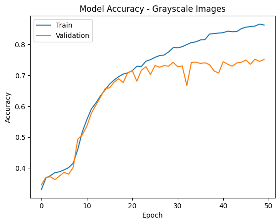

```python
# plot trainging vs validation accuracy on GRAYSCALE images (epoch 1-50)
plt.plot(cnn_history_3c2.history['accuracy'])
plt.plot(cnn_history_3c2.history['val_accuracy'])
plt.title('Model Accuracy - Grayscale Images')
plt.ylabel('Accuracy')
plt.xlabel('Epoch')
plt.legend(['Train', 'Validation'], loc = 'upper left')
# Display the plot
plt.show()
```

```python
# train the model for an additional 50 epochs
cnn_history_3c2 = cnn_model_3c2.fit(
                x_train_norm_2, y_train_encoded_2,
                epochs = 50,
                batch_size= 32,
                validation_data = (x_val_norm_2, y_val_encoded_2),
                verbose = 1
                )
```

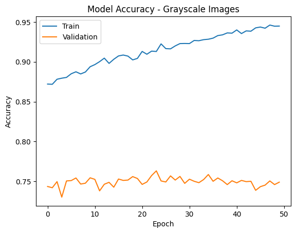

```python
# plot trainging vs validation accuracy on GRAYSCALE images (epoch 51-100)
plt.plot(cnn_history_3c2.history['accuracy'])
plt.plot(cnn_history_3c2.history['val_accuracy'])
plt.title('Model Accuracy - Grayscale Images')
plt.ylabel('Accuracy')
plt.xlabel('Epoch')
plt.legend(['Train', 'Validation'], loc = 'upper left')
# Display the plot
plt.show()
```

```python
# see how the model performs on the GRAYSCALE test data\
y_pred=cnn_model_3c2.predict(x_test_norm_GRAY)
y_pred_arg=np.argmax(y_pred,axis=1)
y_test_arg=np.argmax(y_test_encoded,axis=1)
#this will provide a key to make it clear which numbers refer to which classes
print(emotion_dict)
#Accuracy as per the classification report
cr=metrics.classification_report(y_test_arg,y_pred_arg)
print(cr)
```

```
{'happy': 0, 'sad': 1, 'neutral': 2, 'surprise': 3}
              precision    recall  f1-score   support

           0       0.93      0.93      0.93        30
           1       0.94      0.94      0.94        31
           2       0.94      0.94      0.94        31
           3       1.00      1.00      1.00        19

    accuracy                           0.95       111
   macro avg       0.95      0.95      0.95       111
weighted avg       0.95      0.95      0.95       111
```

```python
# let's check for overlap (duplicate images) between the training data of our new datast and our original test data
image_hash_train = train_data_df_2['image hash'].to_frame() # image hash column of original image_df
image_hash_test = test_data_df['image hash'].to_frame() #image hash of our original test dataframe
unionData = image_hash_test.merge(image_hash_train, how = 'inner' ,indicator=False)
print(unionData.shape)
```

```
(109, 1)
```

**Observations:** cnn_model_3c2 on alternative dataset

- we observed the same phenomenon while training the model on a new dataset, accuracy on the validation data maxed out around 75% while accuracy on the training data continued to improve
- this gives me greater confidence that about 25% of images are simply more difficult to classify (as opposed to there being something systematically wrong with our data)
- we saw very favorable accuracy when testing the model on the test data, but it turns out this number is misleading as almost all of the test images are contained within the training data of the new dataset!
- let's see if if adding depth to our CNN (ie adding convolutional layers) can continue to improve our model

## Deminishing Return on Architecture Complexity (cnn_model_3c3)

```python
def cnn_model_3c3():
  model = Sequential()

  #let's repeat each layer but increase the dropout rate to see if we can prevent the divergence between validation and training accuracies

  model.add(Conv2D(64, (2, 2), padding="same", input_shape = (48,48,1), activation = 'relu'))
  model.add(BatchNormalization())
  model.add(LeakyReLU(0.1))
  #model.add(MaxPooling2D(pool_size=(2, 2)))
  model.add(Dropout(.2))

## duplicate substructure
  model.add(Conv2D(64, (2, 2), padding="same", activation = 'relu'))
  model.add(BatchNormalization())
  model.add(LeakyReLU(0.1))
  #model.add(MaxPooling2D(pool_size=(2, 2)))
  model.add(Dropout(.2))

  model.add(Conv2D(64, (2, 2), padding="same", activation = 'relu'))
  model.add(BatchNormalization())
  model.add(LeakyReLU(0.1))
  # model.add(MaxPooling2D(pool_size=(2, 2)))
  model.add(Dropout(.2))

## duplicate substructure
  model.add(Conv2D(64, (2, 2), padding="same", activation = 'relu'))
  model.add(BatchNormalization())
  model.add(LeakyReLU(0.1))
  # model.add(MaxPooling2D(pool_size=(2, 2)))
  model.add(Dropout(.2))

  model.add(Conv2D(128, (2, 2), padding="same", activation = 'relu'))
  model.add(BatchNormalization())
  model.add(LeakyReLU(0.1))
  #model.add(MaxPooling2D(pool_size=(2, 2)))
  model.add(Dropout(.2))

## duplicate substructure
  model.add(Conv2D(128, (2, 2), padding="same", activation = 'relu'))
  model.add(BatchNormalization())
  model.add(LeakyReLU(0.1))
  #model.add(MaxPooling2D(pool_size=(2, 2)))
  model.add(Dropout(.2))

  model.add(Conv2D(128, (2, 2), padding="same", activation = 'relu'))
  model.add(BatchNormalization())
  model.add(LeakyReLU(0.1))
  model.add(MaxPooling2D(pool_size=(2, 2)))
  model.add(Dropout(.2))

## duplicate substructure
  model.add(Conv2D(128, (2, 2), padding="same", activation = 'relu'))
  model.add(BatchNormalization())
  model.add(LeakyReLU(0.1))
  model.add(MaxPooling2D(pool_size=(2, 2)))
  model.add(Dropout(.2))

  model.add(Conv2D(256, (2, 2), padding="same", activation = 'relu'))
  model.add(BatchNormalization())
  model.add(LeakyReLU(0.1))
  model.add(MaxPooling2D(pool_size=(2, 2)))
  model.add(Dropout(.2))

## duplicate substructure
  model.add(Conv2D(256, (2, 2), padding="same", activation = 'relu'))
  model.add(BatchNormalization())
  model.add(LeakyReLU(0.1))
  model.add(MaxPooling2D(pool_size=(2, 2)))
  model.add(Dropout(.2))

  model.add(Conv2D(256, (2, 2), padding="same", activation = 'relu'))
  model.add(BatchNormalization())
  model.add(LeakyReLU(0.1))
  model.add(MaxPooling2D(pool_size=(2, 2)))
  model.add(Dropout(.2))

## dupicate substructure
  model.add(Conv2D(256, (2, 2), padding="same", activation = 'relu'))
  model.add(BatchNormalization())
  model.add(LeakyReLU(0.1))
  # model.add(MaxPooling2D(pool_size=(2, 2)))
  model.add(Dropout(.2))

  model.add(Conv2D(128, (2, 2), padding="same", activation = 'relu'))
  model.add(BatchNormalization())
  model.add(LeakyReLU(0.1))
  # model.add(MaxPooling2D(pool_size=(2, 2)))
  model.add(Dropout(.2))

## duplicate substructure
  model.add(Conv2D(128, (2, 2), padding="same", activation = 'relu'))
  model.add(BatchNormalization())
  model.add(LeakyReLU(0.1))
  # model.add(MaxPooling2D(pool_size=(2, 2)))
  model.add(Dropout(.2))

  model.add(Flatten())  ## =================================== FLATTEN LAYER ===

  model.add(Dense(256, activation = 'relu'))
  model.add(BatchNormalization())
  model.add(LeakyReLU(0.1))
  model.add(Dropout(.2))

  model.add(Dense(512, activation = 'relu'))
  model.add(BatchNormalization())
  model.add(LeakyReLU(0.1))
  model.add(Dropout(.2))

  model.add(Dense(512, activation = 'relu'))
  model.add(BatchNormalization())
  model.add(LeakyReLU(0.1))
  model.add(Dropout(.2))

  model.add(Dense(512, activation = 'relu'))
  model.add(BatchNormalization())
  model.add(LeakyReLU(0.1))
  model.add(Dropout(.2))

  model.add(Dense(512, activation = 'relu'))
  model.add(BatchNormalization())
  model.add(LeakyReLU(0.1))
  model.add(Dropout(.2))

  model.add(Dense(256, activation = 'relu'))
  model.add(BatchNormalization())
  model.add(LeakyReLU(0.1))
  model.add(Dropout(.2))

  model.add(Dense(4, activation='softmax'))


  # Compile model
  model.compile(loss = 'categorical_crossentropy',
              metrics = ['accuracy'],
              optimizer=tf.keras.optimizers.Adam(learning_rate=0.001))

  return model
```

```python
##load/compile model
cnn_model_3c3 = cnn_model_3c3()
```

```python
#train model
cnn_history_3c3 = train_model(cnn_model_3c3, 50, 'GRAY')
```

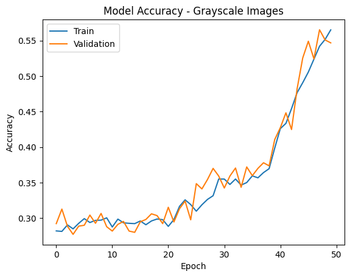

```python
#plot performance (epochs 1-50)
plot_model(cnn_history_3c3, 'GRAY')
```

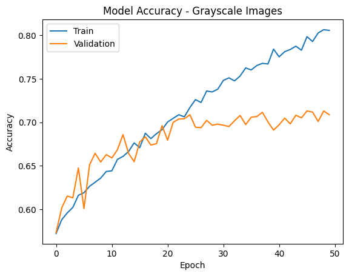

```python
#plot performance (epochs 51 - 100)
plot_model(cnn_history_3c3, 'GRAY')
```

```python
#test model
test_model(cnn_model_3c3, 'GRAY')
```

```
{'happy': 0, 'sad': 1, 'neutral': 2, 'surprise': 3}
              precision    recall  f1-score   support

           0       0.88      0.77      0.82        30
           1       0.68      0.84      0.75        31
           2       0.75      0.77      0.76        31
           3       0.87      0.68      0.76        19

    accuracy                           0.77       111
   macro avg       0.80      0.77      0.78       111
weighted avg       0.79      0.77      0.78       111
```

**Observations:** cnn_model_3c3

- once again we observe a divergence in training vs vaidation accuracy once validation accuracy hits about 70%
- the model showed a slight improvement in accuracy on the test data, but suffered from meaningfully more complexity from increased layers (which resulted in meaningfully slower training times)
- After doubling the number of convolutional 'substructures' we only saw a 1% improvement in accuracy, so we seem to be reaching a point of deminishing return based on architectural changes alone. It seems like our time will be better spent tweaking other aspects of our model
- we will continue to work with cnn_model_3c2 as it was very similar performance-wise but much faster to train
- we should experiment with model hyperparameters, but first let's apply some image augmentation to add to our data set (and hopefully improve generalized learning and break through this 70% - 75% accuracy wall we keep running into)

## **Training with Augmented Data**

```python
#set the parameters for image augmentation
datagen= ImageDataGenerator(
      rotation_range = 25,
      width_shift_range = .20,
      height_shift_range = .20,
      shear_range = .2,
      zoom_range = .2,
      horizontal_flip = True,
      fill_mode='nearest'
)
```

```python
##load/compile model
cnn_model_3c2 = cnn_model_3c2()
```

```python
# train model on original training dataset
cnn_history_3c2_aug = train_model(cnn_model_3c2, 75, 'GRAY')
```

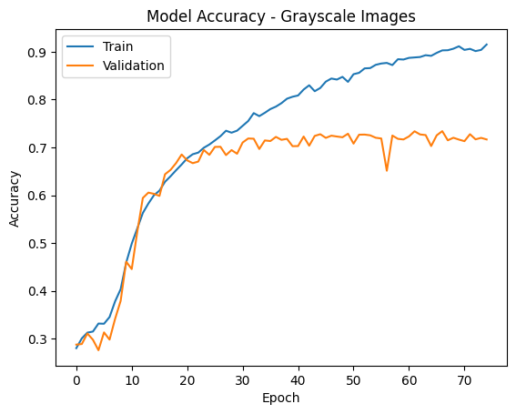

```python
#plot performance on original images (epochs 0 to 75)
plot_model(cnn_history_3c2_aug, 'GRAY')
```

```python
train_generator = datagen.flow(x_train_norm_GRAY, y_train_encoded, batch_size = 32)

#train the model on the augmented images
cnn_history_3c2_aug = cnn_model_3c2.fit_generator(
                train_generator,
                epochs = 75,
                validation_data = (x_val_norm_GRAY, y_val_encoded),
                verbose = 1
                )
```

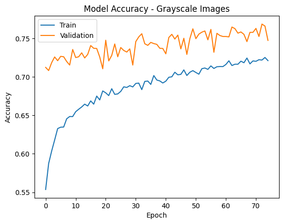

```python
#plot performance (over epochs 76 to 150)
plot_model(cnn_history_3c2_aug, 'GRAY')
```

```python
#test model
test_model(cnn_model_3c2, 'GRAY')
```

```
{'happy': 0, 'sad': 1, 'neutral': 2, 'surprise': 3}
              precision    recall  f1-score   support

           0       0.81      0.87      0.84        30
           1       0.75      0.48      0.59        31
           2       0.56      0.74      0.64        31
           3       0.94      0.89      0.92        19

    accuracy                           0.73       111
   macro avg       0.77      0.75      0.75       111
weighted avg       0.75      0.73      0.73       111
```

```python
train_generator = datagen.flow(x_train_norm_GRAY, y_train_encoded, batch_size = 32)

#train the model on augmented images for another 75  epochs
cnn_history_3c2_aug2 = cnn_model_3c2.fit_generator(
                train_generator,
                epochs = 75,
                validation_data = (x_val_norm_GRAY, y_val_encoded),
                verbose = 1
                )
```

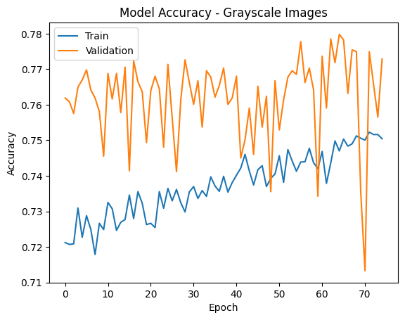

```python
 #plot performance (over epochs 151 to 225)
plot_model(cnn_history_3c2_aug2, 'GRAY')
```

```python
#test model
test_model(cnn_model_3c2, 'GRAY')
```

```
{'happy': 0, 'sad': 1, 'neutral': 2, 'surprise': 3}
              precision    recall  f1-score   support

           0       0.92      0.80      0.86        30
           1       0.81      0.71      0.76        31
           2       0.68      0.87      0.76        31
           3       0.89      0.84      0.86        19

    accuracy                           0.80       111
   macro avg       0.83      0.81      0.81       111
weighted avg       0.82      0.80      0.80       111
```

```python
train_generator = datagen.flow(x_train_norm_GRAY, y_train_encoded, batch_size = 32)

#train the model on augmented images for another 100  epochs
cnn_history_3c2_aug3 = cnn_model_3c2.fit_generator(
                train_generator,
                epochs = 100,
                validation_data = (x_val_norm_GRAY, y_val_encoded),
                verbose = 1
                )
```

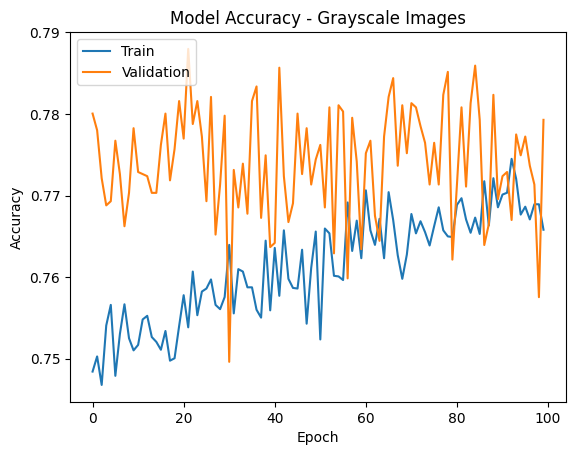

```python
 #plot performance (epochs 225 to 325)
plot_model(cnn_history_3c2_aug3, 'GRAY')
```

```python
#test model
test_model(cnn_model_3c2, 'GRAY')
```

```
{'happy': 0, 'sad': 1, 'neutral': 2, 'surprise': 3}
              precision    recall  f1-score   support

           0       0.90      0.90      0.90        30
           1       0.81      0.71      0.76        31
           2       0.73      0.87      0.79        31
           3       0.94      0.84      0.89        19

    accuracy                           0.83       111
   macro avg       0.85      0.83      0.84       111
weighted avg       0.84      0.83      0.83       111
```

**Observations:** cnn_model_3c2 w/ data augmentation

- augmenting the data gave us enough lift to get the model's accuracy on the test data above 80%!
- this strongly suggests that our model would benefit substantially from more images, specifically from a more diverse array of emotion examples
- this makes sense as each emotion has a diverse number of appearances, with more images the more of these appearances we will be able to capture while training our models